# Risk Factor Analysis

## Outcome Variable

**Outcome Variable:** wast_rec90d

## Predictor Variables

**Intervention Variable:** parity

**Adjustment Set:**

- arm
- W_mage
- meducyrs
- feducyrs
- hhwealth_quart
- W_mhtcm
- vagbrth
- W_nrooms
- impfloor
- impsan
- safeh20
- delta_W_mage
- delta_meducyrs
- delta_feducyrs
- delta_hhwealth_quart
- delta_W_mhtcm
- delta_vagbrth
- delta_W_nrooms
- delta_impfloor
- delta_impsan
- delta_safeh20

## Stratifying Variables

The analysis was stratified on these variable(s):

- agecat
- studyid
- country

## Data Summary

| agecat | studyid | country | parity | wast_rec90d | n_cell | n |
| --- | --- | --- | --- | --- | --- | --- |
| 0-24 months | ki1000304b-SAS-CompFeed | INDIA | 1 | 0 | 136 | 814 |
| 0-24 months | ki1000304b-SAS-CompFeed | INDIA | 1 | 1 | 91 | 814 |
| 0-24 months | ki1000304b-SAS-CompFeed | INDIA | 2 | 0 | 110 | 814 |
| 0-24 months | ki1000304b-SAS-CompFeed | INDIA | 2 | 1 | 62 | 814 |
| 0-24 months | ki1000304b-SAS-CompFeed | INDIA | 3+ | 0 | 258 | 814 |
| 0-24 months | ki1000304b-SAS-CompFeed | INDIA | 3+ | 1 | 157 | 814 |
| 0-24 months | ki1000304b-SAS-FoodSuppl | INDIA | 1 | 0 | 30 | 223 |
| 0-24 months | ki1000304b-SAS-FoodSuppl | INDIA | 1 | 1 | 2 | 223 |
| 0-24 months | ki1000304b-SAS-FoodSuppl | INDIA | 2 | 0 | 47 | 223 |
| 0-24 months | ki1000304b-SAS-FoodSuppl | INDIA | 2 | 1 | 3 | 223 |
| 0-24 months | ki1000304b-SAS-FoodSuppl | INDIA | 3+ | 0 | 133 | 223 |
| 0-24 months | ki1000304b-SAS-FoodSuppl | INDIA | 3+ | 1 | 8 | 223 |
| 0-24 months | ki1017093b-PROVIDE | BANGLADESH | 1 | 0 | 52 | 307 |
| 0-24 months | ki1017093b-PROVIDE | BANGLADESH | 1 | 1 | 76 | 307 |
| 0-24 months | ki1017093b-PROVIDE | BANGLADESH | 2 | 0 | 40 | 307 |
| 0-24 months | ki1017093b-PROVIDE | BANGLADESH | 2 | 1 | 63 | 307 |
| 0-24 months | ki1017093b-PROVIDE | BANGLADESH | 3+ | 0 | 36 | 307 |
| 0-24 months | ki1017093b-PROVIDE | BANGLADESH | 3+ | 1 | 40 | 307 |
| 0-24 months | ki1066203-TanzaniaChild2 | TANZANIA, UNITED REPUBLIC OF | 1 | 0 | 90 | 702 |
| 0-24 months | ki1066203-TanzaniaChild2 | TANZANIA, UNITED REPUBLIC OF | 1 | 1 | 158 | 702 |
| 0-24 months | ki1066203-TanzaniaChild2 | TANZANIA, UNITED REPUBLIC OF | 2 | 0 | 83 | 702 |
| 0-24 months | ki1066203-TanzaniaChild2 | TANZANIA, UNITED REPUBLIC OF | 2 | 1 | 155 | 702 |
| 0-24 months | ki1066203-TanzaniaChild2 | TANZANIA, UNITED REPUBLIC OF | 3+ | 0 | 90 | 702 |
| 0-24 months | ki1066203-TanzaniaChild2 | TANZANIA, UNITED REPUBLIC OF | 3+ | 1 | 126 | 702 |
| 0-24 months | ki1101329-Keneba | GAMBIA | 1 | 0 | 44 | 1164 |
| 0-24 months | ki1101329-Keneba | GAMBIA | 1 | 1 | 79 | 1164 |
| 0-24 months | ki1101329-Keneba | GAMBIA | 2 | 0 | 43 | 1164 |
| 0-24 months | ki1101329-Keneba | GAMBIA | 2 | 1 | 66 | 1164 |
| 0-24 months | ki1101329-Keneba | GAMBIA | 3+ | 0 | 429 | 1164 |
| 0-24 months | ki1101329-Keneba | GAMBIA | 3+ | 1 | 503 | 1164 |

[output cut: 168 more lines]

The following strata were considered:

- agecat: 0-24 months, studyid: ki1000304b-SAS-CompFeed, country: INDIA
- agecat: 0-24 months, studyid: ki1000304b-SAS-FoodSuppl, country: INDIA
- agecat: 0-24 months, studyid: ki1017093b-PROVIDE, country: BANGLADESH
- agecat: 0-24 months, studyid: ki1066203-TanzaniaChild2, country: TANZANIA, UNITED REPUBLIC OF
- agecat: 0-24 months, studyid: ki1101329-Keneba, country: GAMBIA
- agecat: 0-24 months, studyid: ki1113344-GMS-Nepal, country: NEPAL
- agecat: 0-24 months, studyid: ki1126311-ZVITAMBO, country: ZIMBABWE
- agecat: 0-24 months, studyid: ki1135781-COHORTS, country: GUATEMALA
- agecat: 0-24 months, studyid: ki1135781-COHORTS, country: INDIA
- agecat: 0-24 months, studyid: ki1135781-COHORTS, country: PHILIPPINES
- agecat: 0-24 months, studyid: kiGH5241-JiVitA-3, country: BANGLADESH
- agecat: 0-6 months, studyid: ki1000304b-SAS-CompFeed, country: INDIA
- agecat: 0-6 months, studyid: ki1000304b-SAS-FoodSuppl, country: INDIA
- agecat: 0-6 months, studyid: ki1017093b-PROVIDE, country: BANGLADESH
- agecat: 0-6 months, studyid: ki1066203-TanzaniaChild2, country: TANZANIA, UNITED REPUBLIC OF
- agecat: 0-6 months, studyid: ki1101329-Keneba, country: GAMBIA
- agecat: 0-6 months, studyid: ki1113344-GMS-Nepal, country: NEPAL
- agecat: 0-6 months, studyid: ki1126311-ZVITAMBO, country: ZIMBABWE
- agecat: 0-6 months, studyid: ki1135781-COHORTS, country: GUATEMALA
- agecat: 0-6 months, studyid: ki1135781-COHORTS, country: INDIA
- agecat: 0-6 months, studyid: ki1135781-COHORTS, country: PHILIPPINES
- agecat: 0-6 months, studyid: kiGH5241-JiVitA-3, country: BANGLADESH
- agecat: 6-24 months, studyid: ki1000304b-SAS-CompFeed, country: INDIA
- agecat: 6-24 months, studyid: ki1000304b-SAS-FoodSuppl, country: INDIA
- agecat: 6-24 months, studyid: ki1017093b-PROVIDE, country: BANGLADESH
- agecat: 6-24 months, studyid: ki1066203-TanzaniaChild2, country: TANZANIA, UNITED REPUBLIC OF
- agecat: 6-24 months, studyid: ki1101329-Keneba, country: GAMBIA
- agecat: 6-24 months, studyid: ki1113344-GMS-Nepal, country: NEPAL
- agecat: 6-24 months, studyid: ki1126311-ZVITAMBO, country: ZIMBABWE
- agecat: 6-24 months, studyid: ki1135781-COHORTS, country: GUATEMALA
- agecat: 6-24 months, studyid: ki1135781-COHORTS, country: INDIA
- agecat: 6-24 months, studyid: ki1135781-COHORTS, country: PHILIPPINES
- agecat: 6-24 months, studyid: kiGH5241-JiVitA-3, country: BANGLADESH

### Dropped Strata

Some strata were dropped due to rare outcomes:

- agecat: 0-24 months, studyid: ki1000304b-SAS-FoodSuppl, country: INDIA
- agecat: 0-6 months, studyid: ki1000304b-SAS-FoodSuppl, country: INDIA
- agecat: 6-24 months, studyid: ki1000304b-SAS-FoodSuppl, country: INDIA
- agecat: 6-24 months, studyid: ki1135781-COHORTS, country: GUATEMALA
- agecat: 6-24 months, studyid: ki1135781-COHORTS, country: INDIA
- agecat: 6-24 months, studyid: kiGH5241-JiVitA-3, country: BANGLADESH

## Methods Detail

We’re interested in the causal parameters $E[Y_a]$ for all values of $a \in \mathcal{A}$. These parameters represent the mean outcome if, possibly contrary to fact, we intervened to set all units to have $A=a$. Under the randomization and positivity assumptions, these are identified by the statistical parameters $\psi_a=E_W[E_{Y|A,W}(Y|A=a,W)]$. In addition, we’re interested in the mean of $Y$, $E[Y]$ under no intervention (the observed mean). We will estimate these parameters by using SuperLearner to fit the relevant likelihood factors – $E_{Y|A,W}(Y|A=a,W)$ and $p(A=a|W)$, and then updating our likelihood fit using a joint TMLE.

For unadjusted analyses ($W=\{\}$), initial likelihoods were estimated using Lrnr_glm to estimate the simple $E(Y|A)$ and Lrnr_mean to estimate $p(A)$. For adjusted analyses, a small library containing Lrnr_glmnet, Lrnr_xgboost, and Lrnr_mean was used.

Having estimated these parameters, we will then use the delta method to estimate relative risks and attributable risks relative to a prespecified baseline level of $A$.

# Results Detail

## Results Plots

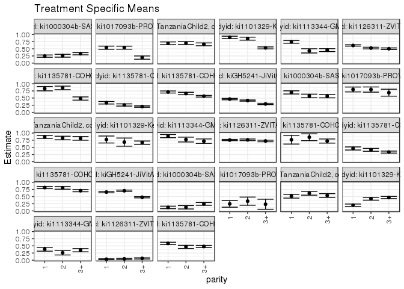

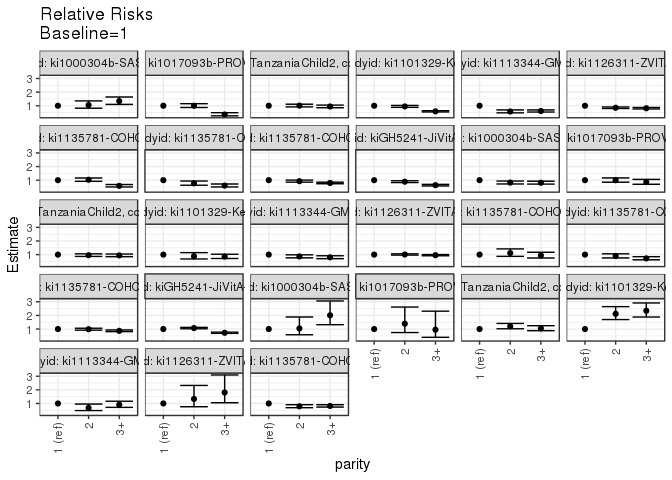

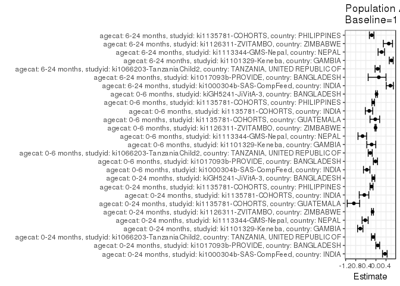

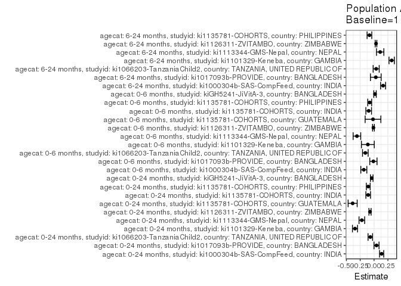

## Results Table

### Parameter: TSM

| agecat | studyid | country | intervention_level | baseline_level | estimate | ci_lower | ci_upper |
| --- | --- | --- | --- | --- | --- | --- | --- |
| 0-24 months | ki1000304b-SAS-CompFeed | INDIA | 1 | NA | 0.2442325 | 0.2043257 | 0.2841392 |
| 0-24 months | ki1000304b-SAS-CompFeed | INDIA | 2 | NA | 0.2577207 | 0.2068992 | 0.3085422 |
| 0-24 months | ki1000304b-SAS-CompFeed | INDIA | 3+ | NA | 0.3281777 | 0.2900998 | 0.3662555 |
| 0-24 months | ki1017093b-PROVIDE | BANGLADESH | 1 | NA | 0.5387249 | 0.4841562 | 0.5932936 |
| 0-24 months | ki1017093b-PROVIDE | BANGLADESH | 2 | NA | 0.5391149 | 0.4859691 | 0.5922608 |
| 0-24 months | ki1017093b-PROVIDE | BANGLADESH | 3+ | NA | 0.1927074 | 0.1362182 | 0.2491966 |
| 0-24 months | ki1066203-TanzaniaChild2 | TANZANIA, UNITED REPUBLIC OF | 1 | NA | 0.6924966 | 0.6445049 | 0.7404883 |
| 0-24 months | ki1066203-TanzaniaChild2 | TANZANIA, UNITED REPUBLIC OF | 2 | NA | 0.6990498 | 0.6483737 | 0.7497258 |
| 0-24 months | ki1066203-TanzaniaChild2 | TANZANIA, UNITED REPUBLIC OF | 3+ | NA | 0.6557113 | 0.6064946 | 0.7049280 |
| 0-24 months | ki1101329-Keneba | GAMBIA | 1 | NA | 0.9004219 | 0.8608805 | 0.9399633 |
| 0-24 months | ki1101329-Keneba | GAMBIA | 2 | NA | 0.8547500 | 0.8025657 | 0.9069344 |
| 0-24 months | ki1101329-Keneba | GAMBIA | 3+ | NA | 0.5316185 | 0.4976778 | 0.5655593 |
| 0-24 months | ki1113344-GMS-Nepal | NEPAL | 1 | NA | 0.7429295 | 0.6938706 | 0.7919884 |
| 0-24 months | ki1113344-GMS-Nepal | NEPAL | 2 | NA | 0.4278042 | 0.3537560 | 0.5018524 |
| 0-24 months | ki1113344-GMS-Nepal | NEPAL | 3+ | NA | 0.4542042 | 0.4043708 | 0.5040375 |
| 0-24 months | ki1126311-ZVITAMBO | ZIMBABWE | 1 | NA | 0.6167637 | 0.5937069 | 0.6398204 |
| 0-24 months | ki1126311-ZVITAMBO | ZIMBABWE | 2 | NA | 0.5256441 | 0.4967531 | 0.5545350 |
| 0-24 months | ki1126311-ZVITAMBO | ZIMBABWE | 3+ | NA | 0.5032035 | 0.4758631 | 0.5305439 |
| 0-24 months | ki1135781-COHORTS | GUATEMALA | 1 | NA | 0.8283020 | 0.7515100 | 0.9050940 |
| 0-24 months | ki1135781-COHORTS | GUATEMALA | 2 | NA | 0.8550074 | 0.7922233 | 0.9177914 |
| 0-24 months | ki1135781-COHORTS | GUATEMALA | 3+ | NA | 0.4843255 | 0.4283432 | 0.5403079 |
| 0-24 months | ki1135781-COHORTS | INDIA | 1 | NA | 0.3364350 | 0.2918115 | 0.3810584 |
| 0-24 months | ki1135781-COHORTS | INDIA | 2 | NA | 0.2582034 | 0.2196559 | 0.2967509 |
| 0-24 months | ki1135781-COHORTS | INDIA | 3+ | NA | 0.2025182 | 0.1784092 | 0.2266272 |
| 0-24 months | ki1135781-COHORTS | PHILIPPINES | 1 | NA | 0.7116170 | 0.6757539 | 0.7474801 |
| 0-24 months | ki1135781-COHORTS | PHILIPPINES | 2 | NA | 0.6591481 | 0.6160898 | 0.7022064 |
| 0-24 months | ki1135781-COHORTS | PHILIPPINES | 3+ | NA | 0.5649797 | 0.5361841 | 0.5937753 |
| 0-24 months | kiGH5241-JiVitA-3 | BANGLADESH | 1 | NA | 0.4643604 | 0.4399382 | 0.4887825 |
| 0-24 months | kiGH5241-JiVitA-3 | BANGLADESH | 2 | NA | 0.4127322 | 0.3919967 | 0.4334677 |
| 0-24 months | kiGH5241-JiVitA-3 | BANGLADESH | 3+ | NA | 0.2940357 | 0.2717659 | 0.3163055 |

[output cut: 51 more lines]

### Parameter: E(Y)

| agecat | studyid | country | intervention_level | baseline_level | estimate | ci_lower | ci_upper |
| --- | --- | --- | --- | --- | --- | --- | --- |
| 0-24 months | ki1000304b-SAS-CompFeed | INDIA | NA | NA | 0.3808354 | 0.3457640 | 0.4159068 |
| 0-24 months | ki1017093b-PROVIDE | BANGLADESH | NA | NA | 0.5830619 | 0.5262762 | 0.6398476 |
| 0-24 months | ki1066203-TanzaniaChild2 | TANZANIA, UNITED REPUBLIC OF | NA | NA | 0.6253561 | 0.5873792 | 0.6633330 |
| 0-24 months | ki1101329-Keneba | GAMBIA | NA | NA | 0.5567010 | 0.5253304 | 0.5880717 |
| 0-24 months | ki1113344-GMS-Nepal | NEPAL | NA | NA | 0.5222816 | 0.4773852 | 0.5671781 |
| 0-24 months | ki1126311-ZVITAMBO | ZIMBABWE | NA | NA | 0.5440559 | 0.5275873 | 0.5605246 |
| 0-24 months | ki1135781-COHORTS | GUATEMALA | NA | NA | 0.4421053 | 0.3904403 | 0.4937702 |
| 0-24 months | ki1135781-COHORTS | INDIA | NA | NA | 0.2306792 | 0.2105836 | 0.2507747 |
| 0-24 months | ki1135781-COHORTS | PHILIPPINES | NA | NA | 0.6068680 | 0.5823645 | 0.6313715 |
| 0-24 months | kiGH5241-JiVitA-3 | BANGLADESH | NA | NA | 0.4226395 | 0.4115127 | 0.4337663 |
| 0-6 months | ki1000304b-SAS-CompFeed | INDIA | NA | NA | 0.5131965 | 0.4596632 | 0.5667297 |
| 0-6 months | ki1017093b-PROVIDE | BANGLADESH | NA | NA | 0.7880435 | 0.7295878 | 0.8464992 |
| 0-6 months | ki1066203-TanzaniaChild2 | TANZANIA, UNITED REPUBLIC OF | NA | NA | 0.7053571 | 0.6558827 | 0.7548316 |
| 0-6 months | ki1101329-Keneba | GAMBIA | NA | NA | 0.6613924 | 0.6093076 | 0.7134773 |
| 0-6 months | ki1113344-GMS-Nepal | NEPAL | NA | NA | 0.5833333 | 0.5108676 | 0.6557991 |
| 0-6 months | ki1126311-ZVITAMBO | ZIMBABWE | NA | NA | 0.7433453 | 0.7262923 | 0.7603982 |
| 0-6 months | ki1135781-COHORTS | GUATEMALA | NA | NA | 0.7476636 | 0.6894668 | 0.8058603 |
| 0-6 months | ki1135781-COHORTS | INDIA | NA | NA | 0.3641405 | 0.3354558 | 0.3928252 |
| 0-6 months | ki1135781-COHORTS | PHILIPPINES | NA | NA | 0.7367021 | 0.7051294 | 0.7682749 |
| 0-6 months | kiGH5241-JiVitA-3 | BANGLADESH | NA | NA | 0.6752588 | 0.6619177 | 0.6885999 |
| 6-24 months | ki1000304b-SAS-CompFeed | INDIA | NA | NA | 0.2854123 | 0.2436284 | 0.3271961 |
| 6-24 months | ki1017093b-PROVIDE | BANGLADESH | NA | NA | 0.2764228 | 0.1950773 | 0.3577682 |
| 6-24 months | ki1066203-TanzaniaChild2 | TANZANIA, UNITED REPUBLIC OF | NA | NA | 0.5519126 | 0.4992021 | 0.6046230 |
| 6-24 months | ki1101329-Keneba | GAMBIA | NA | NA | 0.5176887 | 0.4814695 | 0.5539079 |
| 6-24 months | ki1113344-GMS-Nepal | NEPAL | NA | NA | 0.4934383 | 0.4388573 | 0.5480193 |
| 6-24 months | ki1126311-ZVITAMBO | ZIMBABWE | NA | NA | 0.0699433 | 0.0547084 | 0.0851781 |
| 6-24 months | ki1135781-COHORTS | PHILIPPINES | NA | NA | 0.5026681 | 0.4688378 | 0.5364984 |

### Parameter: RR

| agecat | studyid | country | intervention_level | baseline_level | estimate | ci_lower | ci_upper |
| --- | --- | --- | --- | --- | --- | --- | --- |
| 0-24 months | ki1000304b-SAS-CompFeed | INDIA | 1 | 1 | 1.0000000 | 1.0000000 | 1.0000000 |
| 0-24 months | ki1000304b-SAS-CompFeed | INDIA | 2 | 1 | 1.0552270 | 0.8202153 | 1.3575753 |
| 0-24 months | ki1000304b-SAS-CompFeed | INDIA | 3+ | 1 | 1.3437102 | 1.0995889 | 1.6420292 |
| 0-24 months | ki1017093b-PROVIDE | BANGLADESH | 1 | 1 | 1.0000000 | 1.0000000 | 1.0000000 |
| 0-24 months | ki1017093b-PROVIDE | BANGLADESH | 2 | 1 | 1.0007240 | 0.8708242 | 1.1500009 |
| 0-24 months | ki1017093b-PROVIDE | BANGLADESH | 3+ | 1 | 0.3577102 | 0.2614757 | 0.4893633 |
| 0-24 months | ki1066203-TanzaniaChild2 | TANZANIA, UNITED REPUBLIC OF | 1 | 1 | 1.0000000 | 1.0000000 | 1.0000000 |
| 0-24 months | ki1066203-TanzaniaChild2 | TANZANIA, UNITED REPUBLIC OF | 2 | 1 | 1.0094631 | 0.9143667 | 1.1144498 |
| 0-24 months | ki1066203-TanzaniaChild2 | TANZANIA, UNITED REPUBLIC OF | 3+ | 1 | 0.9468802 | 0.8555356 | 1.0479775 |
| 0-24 months | ki1101329-Keneba | GAMBIA | 1 | 1 | 1.0000000 | 1.0000000 | 1.0000000 |
| 0-24 months | ki1101329-Keneba | GAMBIA | 2 | 1 | 0.9492773 | 0.8816983 | 1.0220359 |
| 0-24 months | ki1101329-Keneba | GAMBIA | 3+ | 1 | 0.5904105 | 0.5464782 | 0.6378746 |
| 0-24 months | ki1113344-GMS-Nepal | NEPAL | 1 | 1 | 1.0000000 | 1.0000000 | 1.0000000 |
| 0-24 months | ki1113344-GMS-Nepal | NEPAL | 2 | 1 | 0.5758341 | 0.4785829 | 0.6928476 |
| 0-24 months | ki1113344-GMS-Nepal | NEPAL | 3+ | 1 | 0.6113691 | 0.5388864 | 0.6936011 |
| 0-24 months | ki1126311-ZVITAMBO | ZIMBABWE | 1 | 1 | 1.0000000 | 1.0000000 | 1.0000000 |
| 0-24 months | ki1126311-ZVITAMBO | ZIMBABWE | 2 | 1 | 0.8522617 | 0.7978872 | 0.9103418 |
| 0-24 months | ki1126311-ZVITAMBO | ZIMBABWE | 3+ | 1 | 0.8158773 | 0.7644032 | 0.8708177 |
| 0-24 months | ki1135781-COHORTS | GUATEMALA | 1 | 1 | 1.0000000 | 1.0000000 | 1.0000000 |
| 0-24 months | ki1135781-COHORTS | GUATEMALA | 2 | 1 | 1.0322411 | 0.9185538 | 1.1599992 |
| 0-24 months | ki1135781-COHORTS | GUATEMALA | 3+ | 1 | 0.5847209 | 0.5020168 | 0.6810501 |
| 0-24 months | ki1135781-COHORTS | INDIA | 1 | 1 | 1.0000000 | 1.0000000 | 1.0000000 |
| 0-24 months | ki1135781-COHORTS | INDIA | 2 | 1 | 0.7674690 | 0.6286944 | 0.9368761 |
| 0-24 months | ki1135781-COHORTS | INDIA | 3+ | 1 | 0.6019535 | 0.5037651 | 0.7192796 |
| 0-24 months | ki1135781-COHORTS | PHILIPPINES | 1 | 1 | 1.0000000 | 1.0000000 | 1.0000000 |
| 0-24 months | ki1135781-COHORTS | PHILIPPINES | 2 | 1 | 0.9262681 | 0.8531827 | 1.0056142 |
| 0-24 months | ki1135781-COHORTS | PHILIPPINES | 3+ | 1 | 0.7939379 | 0.7392417 | 0.8526810 |
| 0-24 months | kiGH5241-JiVitA-3 | BANGLADESH | 1 | 1 | 1.0000000 | 1.0000000 | 1.0000000 |
| 0-24 months | kiGH5241-JiVitA-3 | BANGLADESH | 2 | 1 | 0.8888187 | 0.8265027 | 0.9558332 |
| 0-24 months | kiGH5241-JiVitA-3 | BANGLADESH | 3+ | 1 | 0.6332058 | 0.5775208 | 0.6942600 |

[output cut: 51 more lines]

### Parameter: PAR

| agecat | studyid | country | intervention_level | baseline_level | estimate | ci_lower | ci_upper |
| --- | --- | --- | --- | --- | --- | --- | --- |
| 0-24 months | ki1000304b-SAS-CompFeed | INDIA | 1 | NA | 0.1366029 | 0.0990262 | 0.1741797 |
| 0-24 months | ki1017093b-PROVIDE | BANGLADESH | 1 | NA | 0.0443370 | -0.0010151 | 0.0896891 |
| 0-24 months | ki1066203-TanzaniaChild2 | TANZANIA, UNITED REPUBLIC OF | 1 | NA | -0.0671405 | -0.1078314 | -0.0264495 |
| 0-24 months | ki1101329-Keneba | GAMBIA | 1 | NA | -0.3437209 | -0.3898547 | -0.2975870 |
| 0-24 months | ki1113344-GMS-Nepal | NEPAL | 1 | NA | -0.2206479 | -0.2715459 | -0.1697498 |
| 0-24 months | ki1126311-ZVITAMBO | ZIMBABWE | 1 | NA | -0.0727077 | -0.0919372 | -0.0534783 |
| 0-24 months | ki1135781-COHORTS | GUATEMALA | 1 | NA | -0.3861967 | -0.4677252 | -0.3046683 |
| 0-24 months | ki1135781-COHORTS | INDIA | 1 | NA | -0.1057558 | -0.1475054 | -0.0640062 |
| 0-24 months | ki1135781-COHORTS | PHILIPPINES | 1 | NA | -0.1047490 | -0.1391295 | -0.0703685 |
| 0-24 months | kiGH5241-JiVitA-3 | BANGLADESH | 1 | NA | -0.0417209 | -0.0645729 | -0.0188688 |
| 0-6 months | ki1000304b-SAS-CompFeed | INDIA | 1 | NA | -0.1846050 | -0.2385224 | -0.1306876 |
| 0-6 months | ki1017093b-PROVIDE | BANGLADESH | 1 | NA | -0.0119440 | -0.0774625 | 0.0535746 |
| 0-6 months | ki1066203-TanzaniaChild2 | TANZANIA, UNITED REPUBLIC OF | 1 | NA | -0.1574636 | -0.2083616 | -0.1065655 |
| 0-6 months | ki1101329-Keneba | GAMBIA | 1 | NA | -0.1121374 | -0.2279557 | 0.0036809 |
| 0-6 months | ki1113344-GMS-Nepal | NEPAL | 1 | NA | -0.3090077 | -0.3775124 | -0.2405031 |
| 0-6 months | ki1126311-ZVITAMBO | ZIMBABWE | 1 | NA | -0.0110836 | -0.0270816 | 0.0049144 |
| 0-6 months | ki1135781-COHORTS | GUATEMALA | 1 | NA | -0.0190031 | -0.1607938 | 0.1227875 |
| 0-6 months | ki1135781-COHORTS | INDIA | 1 | NA | -0.0967515 | -0.1478040 | -0.0456989 |
| 0-6 months | ki1135781-COHORTS | PHILIPPINES | 1 | NA | -0.0782603 | -0.1133774 | -0.0431431 |
| 0-6 months | kiGH5241-JiVitA-3 | BANGLADESH | 1 | NA | 0.0173288 | -0.0048308 | 0.0394884 |
| 6-24 months | ki1000304b-SAS-CompFeed | INDIA | 1 | NA | 0.1632396 | 0.1182338 | 0.2082454 |
| 6-24 months | ki1017093b-PROVIDE | BANGLADESH | 1 | NA | 0.0315248 | -0.0648316 | 0.1278812 |
| 6-24 months | ki1066203-TanzaniaChild2 | TANZANIA, UNITED REPUBLIC OF | 1 | NA | 0.0380814 | -0.0165464 | 0.0927091 |
| 6-24 months | ki1101329-Keneba | GAMBIA | 1 | NA | 0.3177143 | 0.2696310 | 0.3657976 |
| 6-24 months | ki1113344-GMS-Nepal | NEPAL | 1 | NA | 0.1104741 | 0.0440376 | 0.1769107 |
| 6-24 months | ki1126311-ZVITAMBO | ZIMBABWE | 1 | NA | 0.0355879 | 0.0210569 | 0.0501188 |
| 6-24 months | ki1135781-COHORTS | PHILIPPINES | 1 | NA | -0.0833107 | -0.1256464 | -0.0409751 |

### Parameter: PAF

| agecat | studyid | country | intervention_level | baseline_level | estimate | ci_lower | ci_upper |
| --- | --- | --- | --- | --- | --- | --- | --- |
| 0-24 months | ki1000304b-SAS-CompFeed | INDIA | 1 | NA | 0.3586928 | 0.2612351 | 0.4432939 |
| 0-24 months | ki1017093b-PROVIDE | BANGLADESH | 1 | NA | 0.0760417 | -0.0018308 | 0.1478611 |
| 0-24 months | ki1066203-TanzaniaChild2 | TANZANIA, UNITED REPUBLIC OF | 1 | NA | -0.1073636 | -0.1764765 | -0.0423108 |
| 0-24 months | ki1101329-Keneba | GAMBIA | 1 | NA | -0.6174245 | -0.7266109 | -0.5151428 |
| 0-24 months | ki1113344-GMS-Nepal | NEPAL | 1 | NA | -0.4224691 | -0.5468695 | -0.3080731 |
| 0-24 months | ki1126311-ZVITAMBO | ZIMBABWE | 1 | NA | -0.1336402 | -0.1704891 | -0.0979513 |
| 0-24 months | ki1135781-COHORTS | GUATEMALA | 1 | NA | -0.8735403 | -1.1345447 | -0.6444505 |
| 0-24 months | ki1135781-COHORTS | INDIA | 1 | NA | -0.4584542 | -0.6601580 | -0.2812567 |
| 0-24 months | ki1135781-COHORTS | PHILIPPINES | 1 | NA | -0.1726059 | -0.2332013 | -0.1149880 |
| 0-24 months | kiGH5241-JiVitA-3 | BANGLADESH | 1 | NA | -0.0987150 | -0.1544681 | -0.0456544 |
| 0-6 months | ki1000304b-SAS-CompFeed | INDIA | 1 | NA | -0.3597161 | -0.4931943 | -0.2381697 |
| 0-6 months | ki1017093b-PROVIDE | BANGLADESH | 1 | NA | -0.0151565 | -0.1018523 | 0.0647180 |
| 0-6 months | ki1066203-TanzaniaChild2 | TANZANIA, UNITED REPUBLIC OF | 1 | NA | -0.2232395 | -0.3057622 | -0.1459322 |
| 0-6 months | ki1101329-Keneba | GAMBIA | 1 | NA | -0.1695475 | -0.3606642 | -0.0052746 |
| 0-6 months | ki1113344-GMS-Nepal | NEPAL | 1 | NA | -0.5297275 | -0.7092832 | -0.3690337 |
| 0-6 months | ki1126311-ZVITAMBO | ZIMBABWE | 1 | NA | -0.0149105 | -0.0367260 | 0.0064461 |
| 0-6 months | ki1135781-COHORTS | GUATEMALA | 1 | NA | -0.0254167 | -0.2337815 | 0.1477589 |
| 0-6 months | ki1135781-COHORTS | INDIA | 1 | NA | -0.2656982 | -0.4198079 | -0.1283159 |
| 0-6 months | ki1135781-COHORTS | PHILIPPINES | 1 | NA | -0.1062306 | -0.1569990 | -0.0576899 |
| 0-6 months | kiGH5241-JiVitA-3 | BANGLADESH | 1 | NA | 0.0256624 | -0.0076375 | 0.0578619 |
| 6-24 months | ki1000304b-SAS-CompFeed | INDIA | 1 | NA | 0.5719432 | 0.4082827 | 0.6903375 |
| 6-24 months | ki1017093b-PROVIDE | BANGLADESH | 1 | NA | 0.1140456 | -0.3070302 | 0.3994667 |
| 6-24 months | ki1066203-TanzaniaChild2 | TANZANIA, UNITED REPUBLIC OF | 1 | NA | 0.0689989 | -0.0339786 | 0.1617205 |
| 6-24 months | ki1101329-Keneba | GAMBIA | 1 | NA | 0.6137169 | 0.5293262 | 0.6829765 |
| 6-24 months | ki1113344-GMS-Nepal | NEPAL | 1 | NA | 0.2238864 | 0.0857907 | 0.3411222 |
| 6-24 months | ki1126311-ZVITAMBO | ZIMBABWE | 1 | NA | 0.5088101 | 0.2951091 | 0.6577236 |
| 6-24 months | ki1135781-COHORTS | PHILIPPINES | 1 | NA | -0.1657371 | -0.2588563 | -0.0795060 |